# Bxy strain pangenome analyses

### Figure 5/6B

Characterize frequency of genomic transfer events by their size, characterize the proportion of genes transferred by island size

```r
list.files(file.path(indir,'pairwise_gene_islands'))
```

```
## [1] "Bacteroides_fragilis_events.txt"
## [2] "Bacteroides_fragilis_summary.txt"
## [3] "Bacteroides_ovatus_events.txt"
## [4] "Bacteroides_ovatus_summary.txt"
## [5] "Bacteroides_thetaiotaomicron_events.txt"
## [6] "Bacteroides_thetaiotaomicron_summary.txt"
## [7] "Bacteroides_xylanisolvens_events.txt"
## [8] "Bacteroides_xylanisolvens_summary.txt"
```

```
## # A tibble: 7 x 5
##   iso1                     host.iso1 iso2                    host.iso2 tree_dist
##   <chr>                    <chr>     <chr>                   <chr>         <dbl>
## 1 P21.6E                   gorilla   GCA.003436085.1.ASM343… human        0.0185
## 2 GCA.003468875.1.ASM3468… human     P14.E4                  chimpanz…    0.0194
## 3 GCA.009102685.1.ASM9102… human     P21.11A                 gorilla      0.0346
## 4 GCA.900107825.1.IMG.tax… missing   GCA.900114865.1.IMG.ta… missing      0.0160
## 5 GCA.000210075.1.ASM2100… human     GCA.015551805.1.ASM155… human        0.0179
## 6 GCA.004167295.1.ASM4167… human     GCA.003474645.1.ASM347… human        0.0299
## 7 GCA.003464445.1.ASM3464… human     GCA.009102085.1.ASM910… human        0.0356
```

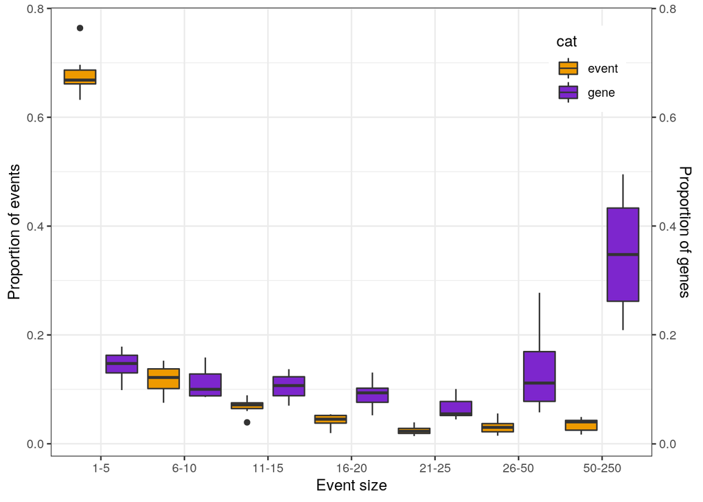

```r
Bxy_prop = read_tsv(
  file.path(indir,'pairwise_gene_islands','Bacteroides_xylanisolvens_events.txt'),
  col_types = cols())
Bov_prop = read_tsv(
  file.path(indir,'pairwise_gene_islands','Bacteroides_ovatus_events.txt'),
  col_types = cols())
Bfr_prop  = read_tsv(
  file.path(indir,'pairwise_gene_islands','Bacteroides_fragilis_events.txt'),
  col_types = cols())
Bth_prop  = read_tsv(
  file.path(indir,'pairwise_gene_islands','Bacteroides_thetaiotaomicron_events.txt'),
  col_types = cols())

compare_prop_events <- function(df) {
  ##Proportions of events/genes by size
  print(distinct(select(df,iso1,host.iso1,iso2,host.iso2,tree_dist)))

  df_gene = df  %>%
      filter(tree_dist>0) %>%
      mutate(cat='gene') %>%
      mutate(size_category=cut(cluster_size, breaks=c(0,5,10,15,20,25,50,250)))
  df_event = df %>%
      distinct(comp,tree_dist,name,cluster_size) %>%
      mutate(cat='event') %>%
      mutate(size_category=cut(cluster_size, breaks=c(0,5,10,15,20,25,50,250)))
  df_combined = df_gene %>% add_row(df_event) %>%
      group_by(cat,size_category,comp) %>%
      summarise(count = n()) %>%
      group_by(cat,comp) %>%
      mutate(total = sum(count),
         freq = count / total)%>%
      as.data.frame()
  df_combined = df_combined %>% mutate(size_category = recode(size_category,
                                '(0,5]'='1-5',
                                '(5,10]'='6-10',
                                '(10,15]'='11-15',
                                '(15,20]'='16-20',
                                '(20,25]'='21-25',
                                '(25,50]'='26-50',
                                '(50,250]'='50-250')
         )
  frac_events_genes = df_combined %>%
      ggplot(aes(x=size_category,y=freq,fill=cat)) +
      geom_boxplot(position=position_dodge(width = 1)) +
      theme_bw() +
      xlab('Event size')+
      scale_y_continuous(
        name = "Proportion of events",
        sec.axis = sec_axis( trans=~., name="Proportion of genes")
        ) +
      theme(
        legend.position = c(.95, .95),
        legend.justification = c(.95, .95)
        ) +
      scale_fill_manual(values = c('orange2','purple3'))
  return(frac_events_genes)
}
(Bxy_prop_plot = compare_prop_events(Bxy_prop))
```

```r
ggsave(Bxy_prop_plot,file=file.path(outdir,'Figure5_Bxy_prop_events_genes.pdf'),width=7,height=5)
Bov_prop_plot = compare_prop_events(Bov_prop)
```

```
## # A tibble: 7 x 5
##   iso1                     host.iso1 iso2                    host.iso2 tree_dist
##   <chr>                    <chr>     <chr>                   <chr>         <dbl>
## 1 GCA.015552185.1.ASM1555… human     GCA.015554355.1.ASM155… human        0.0146
## 2 GCA.000273195.1.Bact.ov… human     GCA.015557585.1.ASM155… human        0.0154
## 3 GCA.000178275.1.ASM1782… human     GCA.015558885.1.ASM155… human        0.0154
## 4 GCA.015549065.1.ASM1554… human     GCA.013361135.1.ASM133… human        0.0163
## 5 GCA.003466305.1.ASM3466… human     GCA.015554165.1.ASM155… human        0.0297
## 6 GCA.900102645.1.IMG.tax… missing   GCA.900100465.1.IMG.ta… missing      0.0353
## 7 GCA.015548845.1.ASM1554… human     GCA.015550085.1.ASM155… human        0.0406
```

```r
Bth_prop_plot = compare_prop_events(Bth_prop)
```

```
## # A tibble: 10 x 5
##    iso1                    host.iso1 iso2                    host.iso2 tree_dist
##    <chr>                   <chr>     <chr>                   <chr>         <dbl>
##  1 GCA.001314975.1.ASM131… human     GCA.001816245.2.ASM181… human        0.0100
##  2 GCA.015547765.1.ASM155… human     GCA.003474005.1.ASM347… human        0.0102
##  3 GCA.003463855.1.ASM346… human     GCA.003469685.1.ASM346… human        0.0102
##  4 GCA.015547465.1.ASM155… human     GCA.015556465.1.ASM155… human        0.0106
##  5 GCA.001405895.1.14207.… human     GCA.015560505.1.ASM155… human        0.0110
##  6 GCA.015551275.1.ASM155… human     GCA.016760105.1.ASM167… missing      0.0110
##  7 GCA.015548485.1.ASM155… human     GCA.003469365.1.ASM346… human        0.0113
##  8 GCA.015556665.1.ASM155… human     GCA.015553025.1.ASM155… human        0.0115
##  9 GCA.003439845.1.ASM343… human     GCA.015551985.1.ASM155… human        0.0128
## 10 GCA.015548265.1.ASM155… human     GCA.015670455.1.ASM156… human        0.0142
```

```r
Bfr_prop_plot = compare_prop_events(Bfr_prop)
```

```
## # A tibble: 11 x 5
##    iso1                        host.iso1 iso2                host.iso2 tree_dist
##    <chr>                       <chr>     <chr>               <chr>         <dbl>
##  1 GCA.014042525.1.ASM1404252… human     GCA.000599185.2.AS… human       0.00549
##  2 GCA.003463555.1.ASM346355v1 human     GCA.900624785.1.82… missing     0.00550
##  3 GCA.000598285.1.ASM59828v1  human     GCA.003469305.1.AS… human       0.00554
##  4 GCA.001699885.1.ASM169988v1 pig       GCA.003439635.1.AS… human       0.00554
##  5 GCA.001699875.1.ASM169987v1 human     GCA.004167855.1.AS… human       0.00554
##  6 GCA.003472025.1.ASM347202v1 human     GCA.015553295.1.AS… human       0.00554
##  7 GCA.003436935.1.ASM343693v1 human     GCA.014042505.1.AS… human       0.00560
##  8 GCA.000599065.2.ASM59906v2  human     GCA.009025705.1.AS… human       0.00578
##  9 GCA.000273135.1.Bact.frag.… human     GCA.003363115.1.AS… human       0.00595
## 10 GCA.001699855.1.ASM169985v1 human     GCA.000598505.1.AS… human       0.00601
## 11 GCA.002811025.1.Bfra.1284.… human     GCA.000598765.2.AS… human       0.00604
```

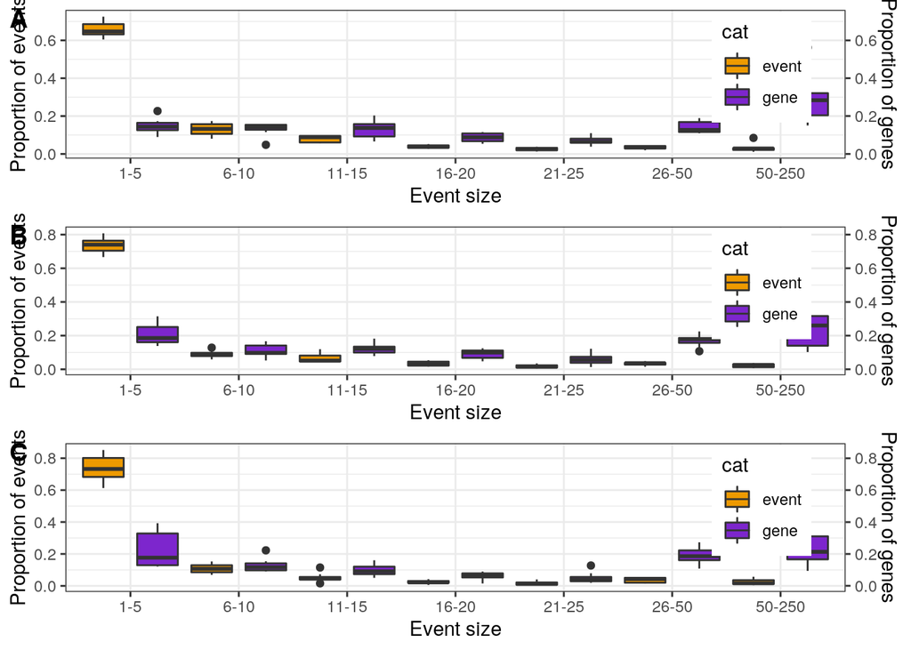

```r
(Bt_prop_other = plot_grid(Bov_prop_plot,Bfr_prop_plot,Bth_prop_plot,ncol=1,labels=c('A','B','C')))
```

```r
ggsave(Bt_prop_other,file=file.path(outdir,'FigureS3_Bt_prop_events_genes.pdf'),height=10,width=5)





#50% genes transferred across all Bacteroides species
Bac_prop = Bxy_prop %>% add_row(Bov_prop) %>% add_row(Bfr_prop) %>% add_row(Bth_prop)
Bac_prop = Bac_prop %>% mutate(captive_strain = if_else(
          str_detect(iso2, "^P")|str_detect(iso1, "^P"),1,0))
ave_gene_island = Bac_prop %>%
  group_by(iso1,host.iso1,taxonomy_Species.iso1,iso2,host.iso2,taxonomy_Species.iso2,captive_strain) %>%
  summarize(ave_gene_island_size=median(cluster_size))
Bt_P50 = ave_gene_island %>%
  ggplot(aes(x=taxonomy_Species.iso1,
             y=ave_gene_island_size,
             color=taxonomy_Species.iso1)) +
  theme_bw() +
  geom_point(size=3)+
  ylab('P50 event size') +
  xlab('Bacteroides species')+
  theme(axis.text.x=element_blank()) +
  scale_colour_manual(values=c('red3','orange','green4','blue4'))
kruskal.test(ave_gene_island_size ~ taxonomy_Species.iso1,data=ave_gene_island)
```

```
##
##  Kruskal-Wallis rank sum test
##
## data:  ave_gene_island_size by taxonomy_Species.iso1
## Kruskal-Wallis chi-squared = 2.0876, df = 3, p-value = 0.5544
```

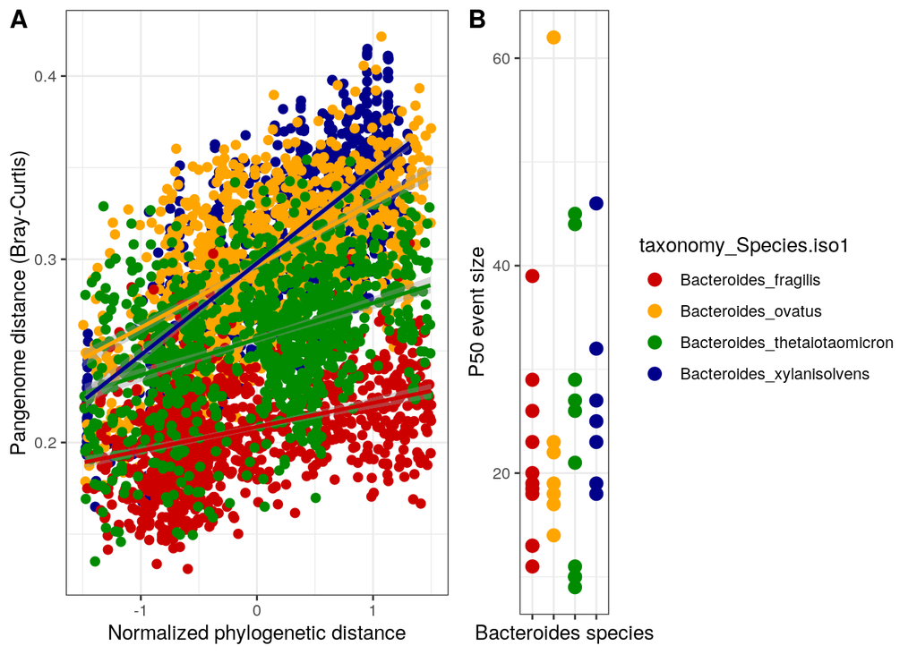

```r
(Bt_pangenome_P50 = plot_grid(Bt_pangenome+theme(legend.position="none"),Bt_P50,labels=c('A','B')))
```

```r
ggsave(Bt_pangenome_P50,file = file.path(outdir,'Figure6_Bacteroides_pangenome_P50.pdf'),width=10,height=4)
```

We hypothesized that comparisons between captive ape and human-associated strains would exhibit a higher proportion of larger events relative to human vs. humans comparisons. We found that captive ape vs. human-associated strain comparisons tended to have a greater proportion of events >50 genes in length, while human vs. human comparison had the greatest proportion of events in the range of 25-50 genes (Figure S1).

```r
##Compare Proportions of genes
Bxy_gene = Bxy_prop  %>%
    filter(tree_dist>0) %>%
    mutate(cat='gene') %>%
    mutate(size_category=cut(cluster_size, breaks=c(0,5,10,15,20,25,50,250))) %>%
    mutate(captive_strain = if_else(
          str_detect(iso2, "^P")|str_detect(iso1, "^P"),1,0)) #all isolates start with P
#determine proportions
Bxy_gene_freq = Bxy_gene  %>%
      group_by(cat,size_category,comp,captive_strain) %>%
      summarise(count = n()) %>%
      group_by(cat,comp) %>%
      mutate(total = sum(count),
         freq = count / total)%>%
      as.data.frame()
Bxy_gene_freq$size_category
```

```
##  [1] (0,5]    (0,5]    (0,5]    (0,5]    (0,5]    (0,5]    (0,5]    (5,10]
##  [9] (5,10]   (5,10]   (5,10]   (5,10]   (5,10]   (5,10]   (10,15]  (10,15]
## [17] (10,15]  (10,15]  (10,15]  (10,15]  (10,15]  (15,20]  (15,20]  (15,20]
## [25] (15,20]  (15,20]  (15,20]  (15,20]  (20,25]  (20,25]  (20,25]  (20,25]
## [33] (20,25]  (20,25]  (20,25]  (25,50]  (25,50]  (25,50]  (25,50]  (25,50]
## [41] (25,50]  (25,50]  (50,250] (50,250] (50,250] (50,250] (50,250] (50,250]
## [49] (50,250]
## Levels: (0,5] (5,10] (10,15] (15,20] (20,25] (25,50] (50,250]
```

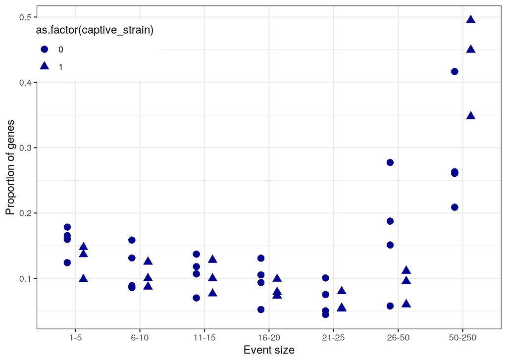

```r
Bxy_gene_freq = Bxy_gene_freq %>%
  mutate(size_category = recode(size_category,
                                '(0,5]'='1-5',
                                '(5,10]'='6-10',
                                '(10,15]'='11-15',
                                '(15,20]'='16-20',
                                '(20,25]'='21-25',
                                '(25,50]'='26-50',
                                '(50,250]'='50-250')
         )


#compare captive vs.human to humanvs.human pairs
(Bxy_captive_vs_human = Bxy_gene_freq %>%
      ggplot(aes(x=size_category,y=freq,
             shape=as.factor(captive_strain))) +
      geom_point(position=position_dodge(width=.5),size=3,color='blue4') +
      theme_bw() +
      xlab('Event size')+
      ylab("Proportion of genes")+
      theme(
        legend.position = c(.25, .95),
        legend.justification = c(.95, .95)
        ))
```

```r
ggsave(Bxy_captive_vs_human,file=file.path(outdir,'FigureS1_Bxy_captive_vs_human.pdf'),
       height=10,width=5)
```